# Assignment 2: We Tank!

Introduction to Software Engineering (CSSE 1001)  
**Due: 24 October 2025, 15:00 GMT+10**

Author

Course Staff (Communal Document)

Published

October 15, 2025

## Changelog

- 26/09/25:
  - Initial Release.
- 1/10/2025:
  - Added missing `fire` entry to Table 1
  - Corrected incorrect constant names in Table 2
- 15/10/2025:
  - Fixed incorrectly listed step in instructions for `load F` in Table 1.

## Introduction

Tanks! is widely considered the best game in the compilation *Wii Play*. In this assignment, you will be implementing a text based game (very) loosely based on this title. In this game, players command a tank with the sole objective of destroying all enemy tanks within a grid-based battlefield. The challenge is that tanks can only move forward and backwards, and must take the time turning left or right. So, one must choose positioning wisely! Note that this task sheet takes precedence in the event it describes differences in gameplay from the original *Tanks!*

## Getting Started

Download `a2.zip` from Blackboard. This archive contains the necessary files to start your assignment. Once extracted, the `a2.zip` archive will provide the following files:

- `a2.py`: *This is the only file you will submit* and is where you write your code. *Do not* make changes to any other files.
- `support.py`: *Do not modify or submit this file*, it contains pre-defined constants to use in your assignment. In addition to these, you are encouraged to create your own constants in `a2.py` where possible.
- `display.py`: *Do not modify or submit this file*, it contains view classes to display your assignment in a visually appealing manner.
- `gameplay/`: This folder contains a number of example outputs generated by playing the game using a fully-functional completed solution to this assignment. The purpose of the files in this folder is to help you understand how the game works, and how output should be formatted.
- `levels/` This folder contains a small collection of files used to initialize games of *We Tank*. In addition to these, you are encouraged to create your own files to help test your implementation where possible.

If you also wish to download this task sheet you must first click `View Fullscreen` at the top of the page. This will open the task sheet in a new browser tab. On this tab, use `Ctrl-P` to print the page, and select `Save to PDF` as the output location. The print button on Blackboard only captures the first two or so pages of this sheet (a limitation of Blackboard beyond our control).

**Caution**

The task sheet may be modified throughout the course of the assignment as issues are identified. These updates will appear online, but will **not** be reflected in a previously downloaded copy. Please regularly check the changelog **online** to ensure you are working with the most up to date version of the task sheet.

## Gameplay

This section provides a high-level overview of gameplay, and is intended to provide you with an idea of the behaviour of a fully completed assignment. Where interactions are not explicitly mentioned in this section, please see the Implementation section.

**Important**

Do not simply implement the behaviour described here using your own structure; you *must* implement the individual functions, classes, and methods described in the Implementation section. Inputs and outputs must match *exactly* what is expected. Refer to the Implementation section, the given examples, and the provided Gradescope tests for clarification on required prompts and outputs.

The game revolves around a rectangular *battlefield* that is constructed out of uniformly sized *tiles*. Each tile represents a *position* on the board. On the battlefield sits a number of *tanks*. Tanks are entities that occupy positions on the board, with each position containing at most one tank entity.

Tiles can either be *blocking* or not blocking, with tanks unable to occupy blocking tiles. *Rocks* are special blocking tiles that can be *destroyed* to become not blocking.

Tanks each possess a *heading* and a desired *speed*. The player’s tank is particularly well constructed, and possesses an additional *armour* value. A tank’s heading denotes the direction the tank will move when it attempts to move forward. The tank’s desired speed describes how many positions it will attempt to move when advancing forwards. Speed can be negative, denoting that the tank will attempt to move backwards instead. Importantly: Tanks can *fire* their cannon forward. When a tank fires, it *hits* the closest tank or blocking tile in the direction of its heading. If the player hits a rock or an enemy tank, it is destroyed. When an enemy tank is destroyed, it is immediately removed from the game. If an enemy tank hits another tank, it applies an *effect* which disrupts that tank’s position. If the tank hit by an enemy is the player, the player loses one armour. The player is destroyed when their armour reaches zero.

Gameplay is conducted in turns. Each turn, the player may take an action. This action may be to move forward or backwards one position, turn left or right by 90 degrees, fire, or to wait in place. After the player has taken their action, each enemy on the battlefield one at a time decides to either fire, or perform a move of their own. When a tank moves, it moves in a straight line given by its heading, moving a number of positions equal to its chosen speed. Moves are resolved one position at a time, and if at any point during a move the tank would move onto a position containing either a blocking tile or another tank, the move ends prematurely.

The game ends when one of the following occurs:

- The player wins, when all tanks except the player are destroyed.
- The player loses, when the player is destroyed.

After starting a game of *We Tank!*, the initial game state is printed to the screen, the player is welcomed using `WELCOME_MSG` from `support.py`, and the following game loop then occurs:

1. The player is repeatedly prompted to enter a command using `COMMAND_PROMPT` from `support.py` until they enter a valid command. Valid commands are given in Table 1.
2. Action is taken as per the command entered by the player. The action that should occur is described in Table 1.
3. One by one, each enemy tank determines and executes a desired action. Details for how actions are selected will be described as relevant in the implementation section.
4. The display is updated by printing the current game state to the screen.
5. If the game is not over, gameplay returns to step 1. Otherwise gameplay advances to step 6.
6. Either `WIN_MSG` or `LOSS_MSG` from `support.py` is printed to the screen informing the player that they won or lost the game as appropriate.
7. The program terminates gracefully.

Table 1: Valid commands and the actions that should be taken. Commands are case insensitive. If the command entered by the user does not exactly match one of the commands in this table (up to case), then no action should be taken, `INVALID_COMMAND_MSG` from `support.py` should be printed to the screen, and gameplay should return immediately to step 1.

[output not shown]

## Implementation

**Important**

You are **not** permitted to add any additional import statements to `a2.py`. Doing so will result in a deduction of up to 100% of your mark. You must not modify or remove the import statements already provided to you in `a2.py`. Removing or modifying these existing import statements may result in your code not functioning, and may result in a deduction of up to 100% of your mark.

### Required Classes and Methods

This section outlines the classes and methods you are **required** to implement in `a2.py`. Your program must operate *exactly* as specified. In particular, your program’s output must match *exactly* with the expected output. Your program will be marked automatically so minor differences in output (such as whitespace or casing) *will* cause tests to fail resulting in *zero marks* for that test.

You will be following the Apple Model-View-Controller design pattern when implementing this assignment. You have been provided the view component, and are required to implement a number of classes in order to complete the Model and Controller components.

The class diagram in Figure 1 provides an overview of all of the classes you must implement in your assignment, and the basic relationships between them. The details of these classes and their methods are described in depth later in this section. Within Figure 1:

- Orange classes are those provided to you in the supporting files.
- Green classes are abstract classes (superclasses). However, you are not required to enforce the abstract nature of the green classes in their implementation. The purpose of this distinction is to indicate to you that you should only ever instantiate the blue classes in your program (though you should instantiate the green classes to test them before beginning work on their subclasses).
- Blue classes are concrete classes (subclasses).
- Solid arrows indicate inheritance (i.e. the “is-a” relationship).
- Dotted arrows indicate composition (i.e. the “has-a” relationship). An arrow marked with 1-1 denotes that each instance of the class at the base of the arrow contains exactly one instance of the class at the head of the arrow. An arrow marked with 1-N denotes that each instance of the class at the base of the arrow may contain many instances of the class at the head of the arrow.

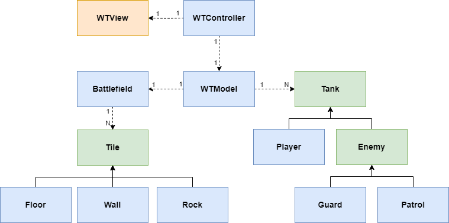

Figure 1: Basic UML diagram for the classes in assignment 2.

**Note**

You are awarded marks for the number of tests passed by your classes when they are tested *independently* of one another. Thus an incomplete assignment with *some* working classes may well be awarded more marks than a complete assignment with faulty classes.

Each class is accompanied with some examples for usage to help you *start* your own testing. You should also test your methods with other values to ensure they operate according to the descriptions.

The rest of this section describes what you must implement in `a2.py` in detail. You should complete the model section before attempting the controller section, ensuring that everything you implement is tested thoroughly, operating correctly, and passes all relevant Gradescope tests. You will not be able to earn marks for the controller section until you have passed all Gradescope tests for the model section.

### Model

The following are the classes and methods you are required to implement as part of the model. You should develop the classes in the order in which they are described in this section and test each one (including on Gradescope) before moving on to the next class. Functionality marks are awarded for each class (and each method) that work correctly. You will likely do very poorly if you submit an attempt at every class, where no classes work according to the description. Some classes require significantly more time to implement than others. The marks allocated to each class are not necessarily an indication of their difficulty or the time required to complete them. You are allowed (and encouraged) to write additional helper methods for any class to help break up long methods, but these helper methods MUST be private (i.e. they must be named with a leading underscore).

**Note**

In the following tasks, you will encounter the `Position` and `Heading` types. These are simply an alias for `tuple[int, int]` used for readability, and are defined in `support.py`

#### Task 1 `Tile()`

`Tile` is an abstract class from which all instantiated types of tile inherit. This class provides default tile behavior, which can be inherited or overridden by specific types of tile. All tiles are represented by a single character identifier, and can either be blocking, or not blocking.

Abstract tiles are not blocking, and are represented by the symbol `T`.

`Tile` must implement the following methods:

- `__init__(self)`  
  Instantiate a new tile.
- `__str__(self) -> str`  
  Returns the identifier that represents this tile.
- `__repr__(self) -> str`  
  Returns a string which could be copied and pasted into a REPL to construct a new instance identical to self.
- `is_blocking(self) -> bool`  
  Returns if this tile is blocking or not.

Example:

```python
>>> tile = Tile()
>>> tile
```

```
Tile()
```

```python
>>> str(tile)
```

```
'T'
```

```python
>>> tile.is_blocking()
```

```
False
```

#### Task 2 `Floor(Tile)`

`Floor` is a non-blocking tile representing walkable ground. Floor tiles are represented by a single space ().

Example:

```python
>>> tile = Floor()
>>> tile
```

```
Floor()
```

```python
>>> str(tile)
```

```
' '
```

```python
>>> tile.is_blocking()
```

```
False
```

#### Task 3 `Wall(Tile)`

`Wall` is a blocking tile representing impassable barriers. Wall tiles are represented by the symbol `W`.

Example:

```python
>>> tile = Wall()
>>> tile
```

```
Wall()
```

```python
>>> str(tile)
```

```
'W'
```

```python
>>> tile.is_blocking()
```

```
True
```

#### Task 4 `Rock(Tile)`

`Rock` is a tile that represents a destructible rock. Rock tiles begin as blocking, but can be destroyed to enable passage. Rock tiles that are not destroyed are represented by the symbol `R`, and rock tiles that have been destroyed are represented by the symbol `X`.

To support this extended functionality, The `__init__` method of `Rock` takes in an additional argument. In addition to the `Tile` methods that must be supported, `Rock` must implement the following methods:

- `__init__(self, is_destroyed: bool)`  
  Instantiate a new `Rock` instance, which is already destroyed if `is_destroyed` is `True`, and not yet destroyed otherwise.
- `is_destroyed(self) -> bool`  
  Return if this rock has been destroyed or not.
- `destroy(self)`  
  Destroy this rock.

Example:

```python
>>> tile = Rock(False)
>>> tile
```

```
Rock(False)
```

```python
>>> str(tile)
```

```
'R'
```

```python
>>> tile.is_blocking()
```

```
True
```

```python
>>> tile.is_destroyed()
```

```
False
```

```python
>>> tile.destroy()
>>> tile
```

```
Rock(True)
```

```python
>>> str(tile)
```

```
'X'
```

```python
>>> tile.is_blocking()
```

```
False
```

```python
>>> tile.is_destroyed()
```

```
True
```

#### Task 5 `Tank()`

`Tank` is an abstract class from which all instantiated types of tank entity inherit. This class provides default entity behavior, which can be inherited or overridden by specific types of tank. Each tank occupies a position, possesses a heading, and has an integer speed value. Positions are represented as (row, column) integer tuples, where `(0, 0)` denotes the top-left corner of the battlefield. Likewise, headings are represented as (row, column) differences, indicating what would be added to the tank’s position if it would move forward. Like tiles, each tank is represented by a single character identifier. Base tanks are represented by the character `K`.

`Tank` must implement the following methods:

- `__init__(self, position: Position, heading: Heading, speed: int)`  
  Instantiate a new tank at the given position, with the specified heading, and speed.
- `__repr__(self) -> str`  
  Returns a string which could be copied and pasted into a REPL to construct a new instance identical to self.
- `__str__(self) -> str`  
  Returns this tank’s identifier, row, column, heading row, heading column, and speed; comma separated.
- `get_id(self) -> str`  
  Returns the single character that represents this tank.
- `get_position(self) -> Position`  
  Returns this tank’s position.
- `set_position(self, new_pos: Position)`  
  Sets this tank’s position to the specified value.
- `get_heading(self) -> Heading`  
  Returns this tank’s heading.
- `set_heading(self, new_heading: Heading)`  
  Sets this tank’s heading to the specified value.
- `get_speed(self) -> int`  
  Returns this tank’s speed.
- `set_speed(self, new_speed: int)`  
  Sets this tank’s speed to the specified value.
- `turn_left(self)`  
  Rotates this tank’s heading 90 degrees left (anticlockwise).
- `turn_right(self)`  
  Rotates this tank’s heading 90 degrees right (clockwise).

**Tip**

A heading can be rotated 90 degrees anticlockwise by swapping the tuple elements and then multiplying the new first element by `-1`. If you are curious as to why this works: It is a special case of applying the [rotation matrix](https://www.geeksforgeeks.org/maths/rotation-matrix/), but flipped as our coordinate system starts in the top left corner!

Example:

```python
>>> tank = Tank((0,0), (0,1), 1)
>>> tank
```

```
Tank((0, 0), (0, 1), 1)
```

```python
>>> str(tank)
```

```
'K,0,0,0,1,1'
```

```python
>>> tank.get_id()
```

```
'K'
```

```python
>>> tank.get_position()
```

```
(0, 0)
```

```python
>>> tank.get_heading()
```

```
(0, 1)
```

```python
>>> tank.get_speed()
```

```
1
```

```python
>>> tank.set_position((3,1))
>>> tank
```

```
Tank((3, 1), (0, 1), 1)
```

```python
>>> tank.set_heading((-1,0))
>>> tank
```

```
Tank((3, 1), (-1, 0), 1)
```

```python
>>> tank.set_speed(42)
>>> tank
```

```
Tank((3, 1), (-1, 0), 42)
```

```python
>>> tank.turn_left()
>>> tank
```

```
Tank((3, 1), (0, -1), 42)
```

```python
>>> tank.turn_right()
>>> tank
```

```
Tank((3, 1), (-1, 0), 42)
```

```python
>>> tank.turn_right()
>>> tank
```

```
Tank((3, 1), (0, 1), 42)
```

```python
>>> tank.set_heading((2,-3))
>>> tank
```

```
Tank((3, 1), (2, -3), 42)
```

```python
>>> tank.turn_right()
>>> tank
```

```
Tank((3, 1), (-3, -2), 42)
```

```python
>>> str(tank)
```

```
'K,3,1,-3,-2,42'
```

#### Task 6 `Player(Tank)`

A `Player` is a tank controlled by the player with upgraded armour. In addition to the regular tank values, a `Player` instance tracks an armour value, and is destroyed only when this value is less than or equal to 0. Player entities are identified by the symbol `P`.

To support this extended functionality, The `__init__` method of `Player` takes in an additional argument. In addition to the `Tank` methods that must be supported, `Player` must implement the following methods:

- `__init__(self, position: Position, heading: Heading, speed: int, armour: int)`  
  Instantiate a new player at the given position, with the specified heading, speed, and armour.
- `__str__(self) -> str`  
  Returns this tank’s identifier, row, column, heading row, heading column, speed, and armour; comma separated.
- `get_armour(self) -> int`  
  Returns this player’s current armour value.
- `set_armour(self, new_armour: int)`  
  Sets this player’s armour to the specified value.
- `is_destroyed(self) -> bool`  
  Returns `True` if this player is destroyed, and `False` otherwise.

Example:

```python
>>> tank = Player((0,0), (0,1), 1, 3)
>>> tank
```

```
Player((0, 0), (0, 1), 1, 3)
```

```python
>>> str(tank)
```

```
'P,0,0,0,1,1,3'
```

```python
>>> tank.get_id()
```

```
'P'
```

```python
>>> tank.get_position()
```

```
(0, 0)
```

```python
>>> tank.get_heading()
```

```
(0, 1)
```

```python
>>> tank.get_speed()
```

```
1
```

```python
>>> tank.get_armour()
```

```
3
```

```python
>>> tank.is_destroyed()
```

```
False
```

```python
>>> tank.set_position((3,1))
>>> tank
```

```
Player((3, 1), (0, 1), 1, 3)
```

```python
>>> tank.set_heading((-1,0))
>>> tank
```

```
Player((3, 1), (-1, 0), 1, 3)
```

```python
>>> tank.set_speed(42)
>>> tank
```

```
Player((3, 1), (-1, 0), 42, 3)
```

```python
>>> tank.turn_left()
>>> tank
```

```
Player((3, 1), (0, -1), 42, 3)
```

```python
>>> tank.turn_right()
>>> tank
```

```
Player((3, 1), (-1, 0), 42, 3)
```

```python
>>> tank.set_armour(-420)
>>> tank
```

```
Player((3, 1), (-1, 0), 42, -420)
```

```python
>>> tank.is_destroyed()
```

```
True
```

#### Task 7 `Enemy(Tank)`

`Enemy` is an abstract class from which all instantiated types of enemy tank inherit. This class provides default enemy behavior, which can be inherited or overridden by specific types of enemy. Enemy tanks possess a degree of autonomy, and can take actions through turning and setting their desired movement speed. These actions are informed by the tiles visible to the enemy. Visible tiles are located in the straight line in front of the enemy, the direction of which is given by the tank’s heading. Enemy tanks also possess the ability to apply effects to tanks that they hit.

Abstract enemies do nothing when taking an action or applying an effect, and are represented by the character `E`.

In addition to the `Tank` methods that must be supported, `Enemy` must implement the following methods:

- `take_action(self, visible_tiles: list[Tile])`  
  Determines and executes the enemy’s desired action based on the tiles visible to it. Tiles should be given in increasing order of distance from the enemy.
- `apply_effect(self, target: Tank)`  
  Applies this enemy’s effect to the specified tank.

**Note**

Instances of the abstract `Enemy` class may ignore the arguments of its `take_action` and `apply_effect` methods, but these methods can be overridden by subclasses.

Example:

```python
>>> tank = Enemy((0,0), (0,1), 1)
>>> tank
```

```
Enemy((0, 0), (0, 1), 1)
```

```python
>>> str(tank)
```

```
'E,0,0,0,1,1'
```

```python
>>> tank.get_id()
```

```
'E'
```

```python
>>> tank.get_position()
```

```
(0, 0)
```

```python
>>> tank.get_heading()
```

```
(0, 1)
```

```python
>>> tank.get_speed()
```

```
1
```

```python
>>> tiles = [Tile(), Floor(), Rock(False), Wall()]
>>> tank.take_action(tiles)
>>> tank
```

```
Enemy((0, 0), (0, 1), 1)
```

```python
>>> tank.get_position()
```

```
(0, 0)
```

```python
>>> tank.get_heading()
```

```
(0, 1)
```

```python
>>> tank.get_speed()
```

```
1
```

```python
>>> punching_bag = Tank((0,0), (0,1), 1)
>>> punching_bag
```

```
Tank((0, 0), (0, 1), 1)
```

```python
>>> tank.apply_effect(punching_bag)
>>> punching_bag
```

```
Tank((0, 0), (0, 1), 1)
```

#### Task 8 `Guard(Enemy)`

`Guard` represents an enemy that guards a fixed location. A guard will always choose to turn 90 degrees left when taking an action. When a guard hits another tank, it sets that tank’s speed to `-2`. Guards are represented by the character `G`

Example:

```python
>>> tank = Guard((0,0), (0,1), 1)
>>> tank
```

```
Guard((0, 0), (0, 1), 1)
```

```python
>>> str(tank)
```

```
'G,0,0,0,1,1'
```

```python
>>> tank.get_id()
```

```
'G'
```

```python
>>> tank.get_position()
```

```
(0, 0)
```

```python
>>> tank.get_heading()
```

```
(0, 1)
```

```python
>>> tank.get_speed()
```

```
1
```

```python
>>> tiles = [Tile(), Floor(), Rock(False), Wall()]
>>> tank.take_action(tiles)
>>> tank
```

```
Guard((0, 0), (-1, 0), 1)
```

```python
>>> tank.get_heading()
```

```
(-1, 0)
```

```python
>>> punching_bag = Tank((0,0), (1,1), 1)
>>> punching_bag
```

```
Tank((0, 0), (1, 1), 1)
```

```python
>>> punching_bag.get_speed()
```

```
1
```

```python
>>> tank.apply_effect(punching_bag)
>>> punching_bag
```

```
Tank((0, 0), (1, 1), -2)
```

```python
>>> punching_bag.get_speed()
```

```
-2
```

#### Task 9 `Patrol(Enemy)`

`Patrol` represents an enemy that patrols a line back and forth. Patrols wish to move with a speed of `2`. So, when taking an action, if more than `2` tiles are visible, this enemy type will set its speed to this desired value. If there are insufficient tiles visible, a patrol will rotate 180 degrees instead. When a patrol hits another tank, it rotates that tank by 180 degrees. Patrols are represented by the character `L`.

Example:

```python
>>> tank = Patrol((0,0), (0,1), 1)
>>> tank
```

```
Patrol((0, 0), (0, 1), 1)
```

```python
>>> str(tank)
```

```
'L,0,0,0,1,1'
```

```python
>>> tank.get_id()
```

```
'L'
```

```python
>>> tank.get_position()
```

```
(0, 0)
```

```python
>>> tank.get_heading()
```

```
(0, 1)
```

```python
>>> tank.get_speed()
```

```
1
```

```python
>>> tiles = [Tile(), Floor(), Rock(False), Wall()]
>>> tank.take_action(tiles)
>>> tank
```

```
Patrol((0, 0), (0, 1), 2)
```

```python
>>> tank.get_heading()
```

```
(0, 1)
```

```python
>>> tank.get_speed()
```

```
2
```

```python
>>> tiles = [Tile(), Wall()]
>>> tank.take_action(tiles)
>>> tank
```

```
Patrol((0, 0), (0, -1), 2)
```

```python
>>> tank.get_heading()
```

```
(0, -1)
```

```python
>>> punching_bag = Tank((0,0), (1,1), 1)
>>> punching_bag
```

```
Tank((0, 0), (1, 1), 1)
```

```python
>>> punching_bag.get_heading()
```

```
(1, 1)
```

```python
>>> tank.apply_effect(punching_bag)
>>> punching_bag
```

```
Tank((0, 0), (-1, -1), 1)
```

```python
>>> punching_bag.get_heading()
```

```
(-1, -1)
```

#### Task 10 `Battlefield()`

`Battlefield` represents a level of *We Tank!*. A battlefield is structured as a rectangular set of tiles.

`Battlefield` must implement the following methods:

- `__init__(self, tiles: list[list[Tile]])`  
  Instantiate a battlefield from the provided tile structure. Tiles should be provided as an ordered list of rows, with the first list in the structure representing the topmost row, and the last list in the structure representing the bottommost row. Each row should be ordered with the first tile representing the leftmost, and the last tile representing the rightmost.
- `__repr__(self) -> str`  
  Returns a string which could be copied and pasted into a REPL to construct a new instance identical to self.
- `__str__(self) -> str`  
  Returns the string representation of each tile in the battlefield, ordered from left to right, grouped into rows from top to bottom separated by new lines.
- `get_tiles(self) -> list[list[Tile]]`  
  Returns the structured set of tiles representing this battlefield, structured as an ordered list of rows, with the first list in the structure representing the topmost row, and the last list in the structure representing the bottommost row. Each row should be ordered with the first tile representing the leftmost, and the last tile representing the rightmost.
- `get_rocks(self) -> dict[Position, Rock]`  
  Returns a dictionary containing all rocks within the battlefield. The keys of the dictionary should be the positions of each rock, and values should be the rock tile at the given position.

Example:

```python
>>> tiles = [[Wall(), Tile(), Rock(False)], [Floor(), Rock(False), Rock(True)]]
>>> battlefield = Battlefield(tiles)
>>> battlefield
```

```
Battlefield([[Wall(), Tile(), Rock(False)], [Floor(), Rock(False), Rock(True)]])
```

```python
>>> str(battlefield)
```

```
'WTR\n RX'
```

```python
>>> battlefield.get_tiles()
```

```
[[Wall(), Tile(), Rock(False)], [Floor(), Rock(False), Rock(True)]]
```

```python
>>> battlefield.get_rocks()
```

```
{(0, 2): Rock(False), (1, 1): Rock(False), (1, 2): Rock(True)}
```

#### Task 11 `WTModel()`

`WTModel` models the logical state of a game of *We Tank!*.

Within this model, the positions visible to a tank are those within the battlefield along the line directly in front of the tank (in the direction of its heading). Visible positions are truncated by positions containing a blocking tile. The position containing the blocking tile is included in the tank’s visible positions, but the tank’s own position is not. A tank’s visible tiles are taken to be the tiles located at the tank’s visible positions. When a tank fires, the position that is hit is the closest visible position containing either a blocking tile or a tank. When an enemy is to take an action under this model: If the player is located within the tank’s visible positions, the enemy will fire, otherwise the enemy will choose and execute an action using its `take_action` method. Here, each enemy is associated with a fixed priority. This priority is used to determine the order in which enemies decide and execute actions, which is important as enemies may move into the path of one another.

`WTModel` must implement the following methods:

- `__init__(self, battlefield: Battlefield, player: Player, enemies: list[Enemy])`  
  Instantiates a new `WTModel` using the given battlefield, player, and enemies. The list of enemies is given in priority order, with the first enemy in the list having highest priority, and the last enemy in the list having lowest priority.
- `__repr__(self) -> str`  
  Returns a string which could be copied and pasted into a REPL to construct a new instance identical to self.
- `__str__(self) -> str`  
  Returns the string representation of the battlefield, followed by two newline characters; followed by the string representation of the player; followed by another newline character; followed finally by the string representation of each enemy in decreasing priority order, separated by newline characters.
- `get_battlefield(self) -> Battlefield`  
  Return this model’s battlefield instance.
- `get_player(self) -> Player`  
  Return this model’s player instance.
- `get_enemies(self) -> list[Enemy]`  
  Return this model’s enemies, in decreasing order of priority.
- `has_won(self) -> bool`  
  Return `True` if the player has won the game per the Gameplay section, and `False` otherwise.
- `has_lost(self) -> bool`  
  Return `True` if the player has lost the game per the Gameplay section, and `False` otherwise.
- `tank_positions(self) -> dict[Position, Tank]`  
  Returns a dictionary containing all tanks within the model. The keys of the dictionary should be the positions of each tank, and values should be the tank entity at the given position.
- `visible_positions(self, tank: Tank) -> list[Position]`  
  Returns the list of positions visible to this tank, in increasing order of distance from the tank. You may assume that `tank` has a heading of exactly one tile either horizontally or vertically.
- `advance_tank(self, tank: Tank)`  
  Moves the given tank according to its heading and chosen speed. Movement should be halted prematurely if the tank would otherwise move to a position containing another tank or a blocking tile. If the tank has a negative speed, movement should occur as if the speed was positive, but the tank should move backwards instead of forward. The tank’s speed should be set to `0` after the move has resolved. You may assume that `tank` has a heading of exactly one tile either horizontally or vertically.
- `get_attack_target(self, tank: Tank) -> Position`  
  Determines the position of the tile or tank that would be hit if the specified tank were to fire. You may assume that the tank *will* hit something. You may assume that `tank` has a heading of exactly one tile either horizontally or vertically.
- `enemy_actions(self)`  
  Has each enemy take an action in priority order, beginning with the highest priority enemy, and ending with the lowest priority enemy. When an enemy hits a tank, its effect should be applied to that tank and the hit tank should then be advanced using `advance_tank`. If the hit tank is the player, their armour should be reduced by one before the effect is applied. After an enemy executes an action using its `take_action` method, it should be advanced using `advance_tank`. You may assume that each enemy has a heading of exactly one tile either horizontally or vertically.
- `player_fire(self)`  
  Has the player fire, and resolves the destruction of any enemy or rock that is hit. You may assume that the player *will* hit something. You may assume that the player has a heading of exactly one tile either horizontally or vertically.
- `player_move(self, move: str)`  
  Moves or turns the player according to `move` as per Table 1. In this method, the player turns in 90 degree intervals, and moves with a speed of `1`. The player’s speed should be set to `0` after the chosen move has resolved. A precondition to this function is that `move` is either `left`, `right`, `forward`, or `back`.

Example:

```python
>>> tiles = [[Wall(),Wall(),Wall(),Wall(),Wall()],[Wall(),Floor(),Wall(),Floor(),Wall()],[Wall(),Rock(False),Floor(),Floor(),Wall()],[Wall(),Floor(),Floor(),Floor(),Wall()],[Wall(),Wall(),Wall(),Wall(),Wall()]]
>>> battlefield = Battlefield(tiles)
>>> player = Player((1,1), (1,0), 2, 2)
>>> enemies = [Guard((2,2), (1,0), 0), Patrol((1,3), (1,0), 0)]
>>> model = WTModel(battlefield, player, enemies)
>>> model
```

[output not shown]

```python
>>> str(model)
```

```
'WWWWW\nW W W\nWR  W\nW   W\nWWWWW\n\nP,1,1,1,0,2,2\nG,2,2,1,0,0\nL,1,3,1,0,0'
```

```python
>>> model.get_battlefield()
```

```
Battlefield([[Wall(), Wall(), Wall(), Wall(), Wall()], [Wall(), Floor(), Wall(), Floor(), Wall()], [Wall(), Rock(False), Floor(), Floor(), Wall()], [Wall(), Floor(), Floor(), Floor(), Wall()], [Wall(), Wall(), Wall(), Wall(), Wall()]])
```

```python
>>> model.get_player()
```

```
Player((1, 1), (1, 0), 2, 2)
```

```python
>>> model.get_enemies()
```

```
[Guard((2, 2), (1, 0), 0), Patrol((1, 3), (1, 0), 0)]
```

```python
>>> model.has_won()
```

```
False
```

```python
>>> model.has_lost()
```

```
False
```

```python
>>> model.tank_positions()
```

```
{(1, 1): Player((1, 1), (1, 0), 2, 2),
 (2, 2): Guard((2, 2), (1, 0), 0),
 (1, 3): Patrol((1, 3), (1, 0), 0)}
```

```python
>>> e1 = model.get_enemies()[0]
>>> e1
```

```
Guard((2, 2), (1, 0), 0)
```

```python
>>> print(model)
```

```
WWWWW
W W W
WR  W
W   W
WWWWW

P,1,1,1,0,2,2
G,2,2,1,0,0
L,1,3,1,0,0
```

```python
>>> model.visible_positions(e1)
```

```
[(3, 2), (4, 2)]
```

```python
>>> model.get_attack_target(e1)
```

```
(4, 2)
```

```python
>>> model.visible_positions(player) # Blocked by rock
```

```
[(2, 1)]
```

```python
>>> model.get_attack_target(player)
```

```
(2, 1)
```

```python
>>> model.player_fire() # Destroy Rock
```

```python
>>> model.visible_positions(player) # No longer blocked
```

```
[(2, 1), (3, 1), (4, 1)]
```

```python
>>> model.get_attack_target(player)
```

```
(4, 1)
```

```python
>>> print(model)
```

```
WWWWW
W W W
WX  W
W   W
WWWWW

P,1,1,1,0,2,2
G,2,2,1,0,0
L,1,3,1,0,0
```

```python
>>> model.enemy_actions() # Patrol moves
```

```python
>>> print(model)
```

```
WWWWW
W W W
WX  W
W   W
WWWWW

P,1,1,1,0,2,2
G,2,2,0,1,0
L,3,3,1,0,0
```

```python
>>> model.enemy_actions() # Patrol Turns
```

```python
>>> print(model)
```

```
WWWWW
W W W
WX  W
W   W
WWWWW

P,1,1,1,0,2,2
G,2,2,-1,0,0
L,3,3,-1,0,0
```

```python
>>> player.get_position()
```

```
(1, 1)
```

```python
>>> player.get_speed()
```

```
2
```

```python
>>> player.get_heading()
```

```
(1, 0)
```

```python
>>> model.advance_tank(player)
```

```python
>>> player.get_position()
```

```
(3, 1)
```

```python
>>> player.get_speed()
```

```
0
```

```python
>>> player.get_heading()
```

```
(1, 0)
```

```python
>>> print(model)
```

```
WWWWW
W W W
WX  W
W   W
WWWWW

P,3,1,1,0,0,2
G,2,2,-1,0,0
L,3,3,-1,0,0
```

```python
>>> model.player_move("back")
```

```python
>>> player.get_position()
```

```
(2, 1)
```

```python
>>> player.get_speed()
```

```
0
```

```python
>>> player.get_heading()
```

```
(1, 0)
```

```python
>>> print(model)
```

```
WWWWW
W W W
WX  W
W   W
WWWWW

P,2,1,1,0,0,2
G,2,2,-1,0,0
L,3,3,-1,0,0
```

```python
>>> model.enemy_actions() # Guard now looking left
```

```python
>>> print(model)
```

```
WWWWW
W W W
WX  W
W   W
WWWWW

P,2,1,1,0,0,2
G,2,2,0,-1,0
L,1,3,-1,0,0
```

```python
>>> model.visible_positions(e1)
```

```
[(2, 1), (2, 0)]
```

```python
>>> model.get_attack_target(e1) # Player in way
```

```
(2, 1)
```

```python
>>> model.enemy_actions() # Guard shoots, knocks back player
```

```python
>>> print(model)
```

```
WWWWW
W W W
WX  W
W   W
WWWWW

P,1,1,1,0,0,1
G,2,2,0,-1,0
L,1,3,1,0,0
```

```python
>>> model.player_move("forward")
```

```python
>>> print(model)
```

```
WWWWW
W W W
WX  W
W   W
WWWWW

P,2,1,1,0,0,1
G,2,2,0,-1,0
L,1,3,1,0,0
```

```python
>>> model.player_move("left") # Looking at guard
```

```python
>>> print(model)
```

```
WWWWW
W W W
WX  W
W   W
WWWWW

P,2,1,0,1,0,1
G,2,2,0,-1,0
L,1,3,1,0,0
```

```python
>>> model.visible_positions(player)
```

```
[(2, 2), (2, 3), (2, 4)]
```

```python
>>> model.get_attack_target(player) # Guard in way
```

```
(2, 2)
```

```python
>>> model.player_fire() # Destroys Guard
```

```python
>>> print(model)
```

```
WWWWW
W W W
WX  W
W   W
WWWWW

P,2,1,0,1,0,1
L,1,3,1,0,0
```

```python
>>> e2 = model.get_enemies()[0]
>>> e2
```

```
Patrol((1, 3), (1, 0), 0)
```

```python
>>> e2.set_position((2,3)) # Move in front of player
>>> print(model)
```

```
WWWWW
W W W
WX  W
W   W
WWWWW

P,2,1,0,1,0,1
L,2,3,1,0,0
```

```python
>>> model.player_fire() # Destroy Patrol
```

```python
>>> print(model)
```

```
WWWWW
W W W
WX  W
W   W
WWWWW

P,2,1,0,1,0,1
```

```python
>>> model.has_won()
```

```
True
```

```python
>>> model.has_lost()
```

```
False
```

```python
>>> player.set_armour(0)
```

```python
>>> model.has_won()
```

```
False
```

```python
>>> model.has_lost()
```

```
True
```

### Controller

The controller is a single class, `WTController()`, which you must implement according to this section. You will also implement the `play_game` function to construct the controller, and the `load_model` function to assist with constructing game states as required. Unlike with the model, there is no recommended task completion order in this section. It will likely be helpful to work on certain tasks in parallel to implement features. Please refer to the `gameplay/` folder provided with this assignment for examples of intended controller behavior. Note that for all such examples, the file initially loaded is `levels/level1.txt`.

#### Task 12 `load_model(file: str) -> WTModel`

`load_model` is a *function* that attempts to load a WTModel from the file located at the path specified by `file`, assuming that it contains *exactly* The string representation of a `WTModel`.

You may assume that the structure of the file is valid (That is, follows the structure of a `WTModel` string representation). But, you **cannot** assume that the values within `file` are valid. This function should raise a `ValueError` if you encounter any of the errors specified in Table 2 (excluding the first row). If a `ValueError` is raised, its message should be that presented in the corresponding row of Table 2.

You should *not* handle the case where `file` does not exist in this function.

#### Task 13 `WTController()`

`WTController()` is the controller class for the overall game. The controller is responsible for maintaining instances of the model and view classes, handling player input, and facilitating communication between the model and view classes.

**Note**

One of the most important skills in programming is the ability to understand and use someone elses code. You will be expected to understand and correctly use the `WTView` class provided in `display.py`.

`WTController()` should implement the following methods:

Table 2: Messages that should be printed given problems with loaded file. Messages are given in order of precedence. That is to say: if multiple errors occur simultaneously, the topmost error in this table should be displayed.

| Error | Message from `support.py` to be printed |
| --- | --- |
| File does not exist | `FILE_NOT_FOUND_MSG` |
| Tiles contain a character that is not a valid `Tile` ID | `INVALID_TILE_MSG` |
| ID of player entity is not `PLAYER_ID`, or player values contain a non-integer | `INVALID_PLAYER_MSG` |
| ID of creature entity is not `ENEMY_ID`, or creature values contain a non-integer | `INVALID_ENEMY_MSG` |

#### Task 14 `play_game(file: str)`

The play game function should be fairly short and do *exactly* three things:

1. Load a `WTModel` instance from the game state located in `file` using the `load_model` function. You may assume that no errors will be raised when loading the `WTModel`.
2. Construct a controller instance with the loaded game state.
3. Play a single game of *We Tank!* from beginning to end (using `.play()`)

#### Task 15 `main()`

The purpose of the main function is to allow you to test your own code. Like the play game function, the main function should be short (A single line) and do exactly one thing: call `play_game` with a file name of your choice.

## Assessment and Marking Criteria

This assignment assesses following course learning objectives:

1. Apply program constructs such as variables, selection, iteration and sub-routines,
2. Apply basic object-oriented concepts such as classes, instances and methods,
3. Read and analyse code written by others,
4. Analyse a problem and design an algorithmic solution to the problem,
5. Read and analyse a design and be able to translate the design into a working program, and
6. Apply techniques for testing and debugging.

There are a total of 100 marks for this assessment item.

### Functionality

Your program’s functionality will be marked out of a total of 50 marks.

The breakdown of marks for each implementation section is as follows:

- Model: 35 Marks
- Controller: 15 Marks

Your assignment will be put through a series of tests and your functionality mark will be proportional to the number of tests you pass. You will be given a *subset* of the functionality tests before the due date for the assignment.

You may receive partial marks within each section for partially working functions, or for implementing only a few functions.

**Warning**

You need to perform your *own* testing of your program to make sure that it meets **all** specifications given in the assignment. Only relying on the provided tests is likely to result in your program failing in some cases and you losing some functionality marks.

**Note**

Functionality tests are automated, so string outputs need to match *exactly* what is expected.

Your program must run in Gradescope, which uses Python 3.12. Partial solutions will be marked but if there are errors in your code that cause the interpreter to fail to execute your program, you will get zero for functionality marks. If there is a part of your code that causes the interpreter to fail, comment out the code so that the remainder can run. Your program must run using the Python 3.12 interpreter. If it runs in another environment (e.g. Python 3.8 or PyCharm) but not in the Python 3.12 interpreter, you will get zero for the functionality mark. Python versions newer than 3.12 will function correctly provided you do not use language features that are not introduced in the course.

### Code Style

The style of your assignment will be assessed by a tutor. Style will be marked according to the style rubric provided with the assignment. The style mark will be out of 50.

**Note**

Style accounts for half the marks available on this assignment

You are expected to follow the [style guidelines](https://edstem.org/au/courses/24636/lessons/87188/slides/594422) discussed in lectures. The key consideration in marking your code style is whether the code is easy to understand. There are several aspects of code style that contribute to how easy it is to understand code. In this assignment, your code style will be assessed against the following criteria:

- Readability
  - Program Structure: Layout of code makes it easy to read and follow its logic. This includes using whitespace to highlight blocks of logic, and ensuring all lines are below 80 characters.
  - Descriptive Identifier Names: Variable, constant, and function names clearly describe what they represent in the program’s logic. Do not use Hungarian Notation for identifiers. In short, this means do not include the identifier’s type in its name, rather make the name meaningful (e.g. employee identifier).
  - Named Constants: Any non-trivial fixed value (literal constant) in the code is represented by a descriptive named constant (identifier).
- Algorithmic Logic
  - Single Instance of Logic: Blocks of code should not be duplicated in your program. Any code that needs to be used multiple times should be implemented as a function.
  - Variable Scope: Variables should be declared locally in the function in which they are needed. Global variables should not be used.
  - Control Structures: Logic is structured simply and clearly through good use of control structures (e.g. loops and conditional statements).
- Object-Oriented Program Structure
  - Classes & Instances: Objects are used as entities to which messages are sent, demonstrating understanding of the differences between classes and instances.
  - Encapsulation: Classes are designed as independent modules with state and behaviour. Methods only directly access the state of the object on which they were invoked. Methods never update the state of another object.
  - Abstraction: Public interfaces of classes are simple and reusable. Enabling modular and reusable components which abstract GUI details.
  - Inheritance & Polymorphism: Subclasses are designed as specialised versions of their superclasses. Subclasses extend the behaviour of their superclass without re-implementing behaviour, or breaking the superclass behaviour or design. Subclasses redefine behaviour of appropriate methods to extend the superclasses’ type. Subclasses do not break their superclass’ interface.
  - Model View Controller: Your program adheres to the Model-View-Controller design pattern. The GUI’s view and control logic is clearly separated from the model. Model information stored in the controller and passed to the view when required.
- Documentation:
  - Comment Clarity: Comments provide meaningful descriptions of the code. They should not repeat what is already obvious by reading the code (e.g. `# Setting variable to 0`). Comments should not be verbose or excessive, as this can make it difficult to follow the code.
  - Informative Docstrings: Every function should have a docstring that summarises its purpose. This includes describing parameters and return values (including type information) so that others can understand how to use the function correctly.
  - Description of Logic: All significant blocks of code should have a comment to explain how the logic works. For a small function, this would usually be the docstring. For long or complex functions, there may be different blocks of code in the function. Each of these should have an in-line comment describing the logic.

### Assignment Submission

You must submit your assignment electronically via [Gradescope](https://gradescope.com/). You **must** use your UQ email address which is based on your student number (e.g. `s4123456@student.uq.edu.au`) as your Gradescope submission account.

When you login to Gradescope you may be presented with a list of courses. Select `CSSE1001`. You will see a list of assignments. Choose `Assignment 2`. You will be prompted to choose a file to upload. Do *not* select the option to submit using a git repository if it is presented to you. The prompt may say that you can upload any files, including zip files. You **must** submit your assignment as a single Python file called `a2.py` (use this name – all lower case), and *nothing* else. Your submission will be automatically run to determine the functionality mark. If you submit a file with a different name, the tests will **fail** and you will get **zero** for functionality. Do **not** submit *any* sort of archive file (e.g. zip, rar, 7z, etc.).

Upload an initial version of your assignment *at least* one week before the due date. Do this even if it is just the initial code provided with the assignment. If you are unable access Gradescope, make a post on [Edstem](https://edstem.org/au/courses/24510) *immediately*. Excuses, such as you were not able to login or were unable to upload a file will not be accepted as reasons for granting an extension.

When you upload your assignment it will run a **subset** of the functionality autograder tests on your submission. It will show you the results of these tests. It is your responsibility to ensure that your uploaded assignment file runs and that it passes the tests you expect it to pass.

Late submission of the assignment will result in a deduction of 100% of the total possible mark. A one-hour grace period will be applied to the due time, after which time (16:00) your submission will be considered officially late and will receive a mark of 0. Do not wait until the last minute to submit your assignment, as the time to upload it may make it late. **Multiple submissions are allowed and encouraged**, so ensure that you have submitted an almost complete version of the assignment *well* before the submission deadline of 15:00. Your latest submission will be marked. Do not submit after the deadline, as this will result in a late penalty of 100% of the maximum possible mark being applied to your submission.

In the event of exceptional personal or medical circumstances that prevent you from handing in the assignment on time, you may submit a request for an extension. See the course profile for details of how to apply for an extension.

Requests for extensions must be made **before** the submission deadline. The application and supporting documentation (e.g. medical certificate) must be submitted via [myUQ](https://my.uq.edu.au/). You must retain the original documentation for a minimum period of six months to provide as verification, should you be requested to do so.

### Plagiarism

This assignment must be your own individual work. By submitting the assignment, you are claiming it is entirely your own work. You may discuss general ideas about the solution approach with other students. Describing details of how you implement a function or sharing part of your code with another student is considered to be **collusion** and will be counted as plagiarism. You **must not** copy fragments of code that you find on the Internet to use in your assignment. You **must not** use any artificial intelligence programs to assist you in writing your assignment.

Please read the section in the course profile about plagiarism. You are encouraged to complete *both* parts A and B of the [academic integrity modules](https://web.library.uq.edu.au/library-services/it/learnuq-blackboard-help/academic-integrity-modules) *before* starting this assignment. Submitted assignments will be electronically checked for potential cases of plagiarism.